# Machine Learning and Pattern Recognition - Assignment I

124384 - Luycer Bosire

6/27/2021

Importing the data:

```r
employeedata<-read.csv("Table_203a.csv")
View(employeedata)
attach(employeedata)
```

We may wish to explore any viable relationships between the variables in the dataset and identify patterns in the variable data.

We test for the presence or absence of a fixed location and a fixed scale in the dataset by plotting various numeric variables against time:

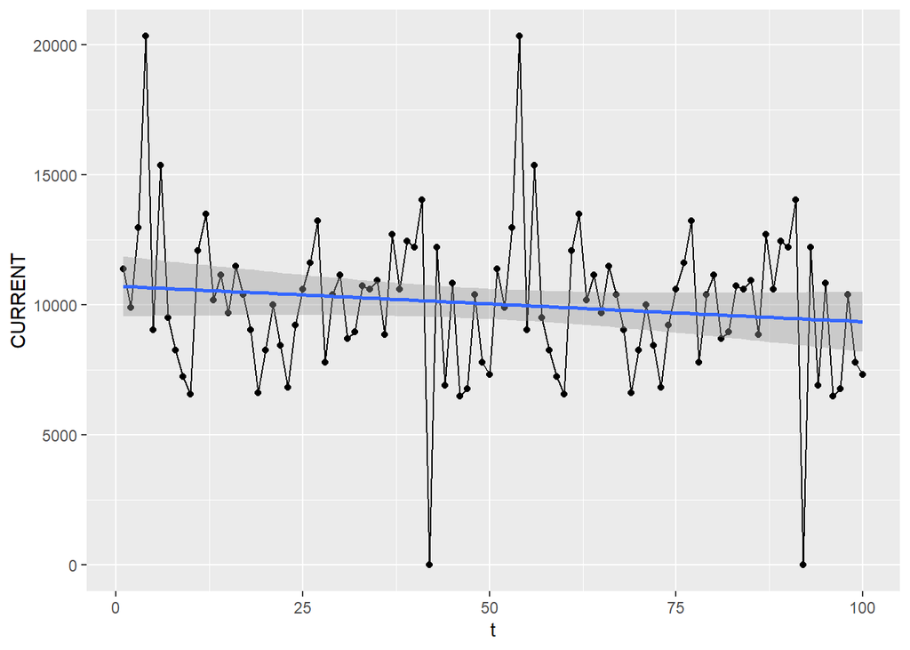

```r
library(ggplot2)
t<-seq(1:length(employeedata$CURRENT)) #We set out time parameter

par(mfrow = c(3,3))
#Run-sequential plot for current salary variable
ggplot(employeedata, aes(x=t, y=CURRENT)) + geom_line() + geom_point() + geom_smooth(method=lm)
```

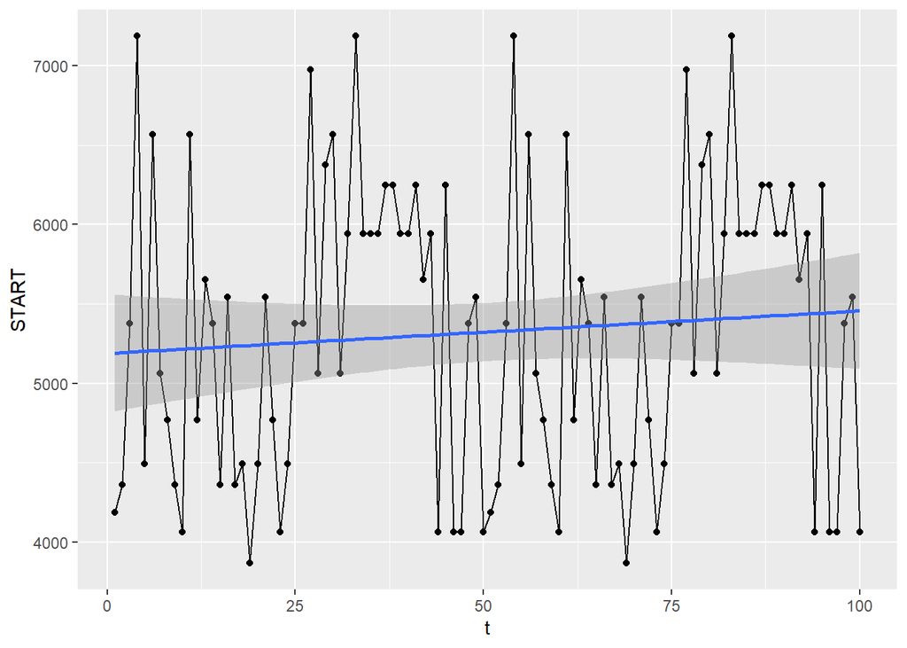

```r
#Run-sequential plot for starting salary variable
ggplot(employeedata, aes(x=t, y=START)) + geom_line() + geom_point() + geom_smooth(method=lm)
```

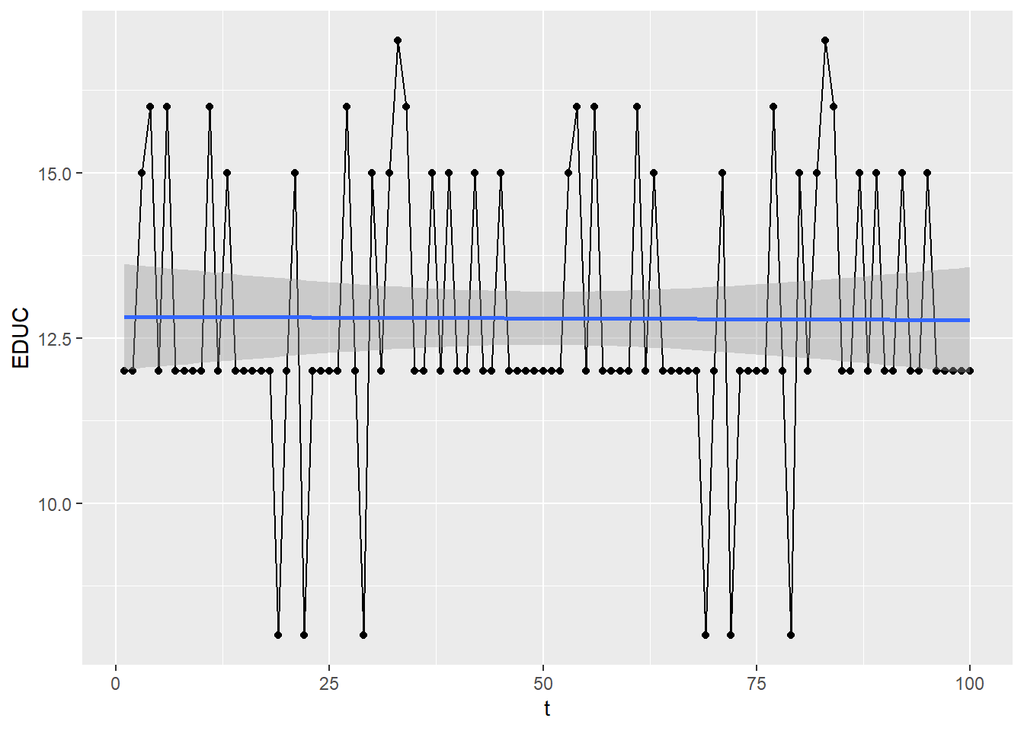

```r
#Run-sequential plot for education variable
ggplot(employeedata, aes(x=t, y=EDUC)) + geom_line() + geom_point() + geom_smooth(method=lm)
```

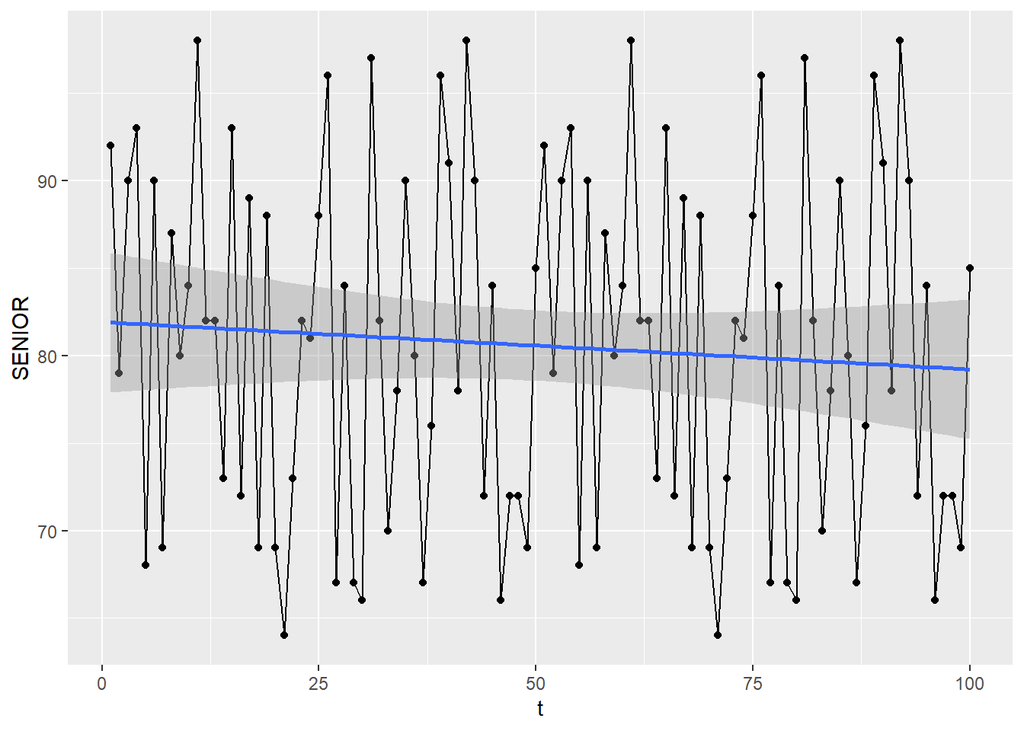

```r
#Run-sequential plot for seniority level variable
ggplot(employeedata, aes(x=t, y=SENIOR)) + geom_line() + geom_point() + geom_smooth(method=lm)
```

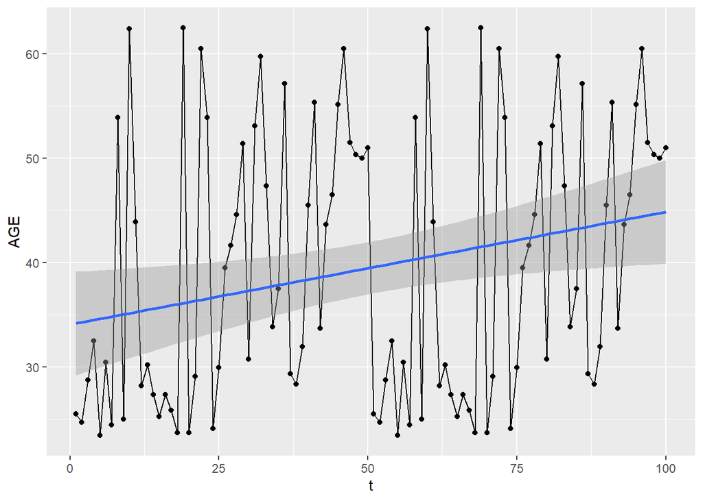

```r
#Run-sequential plot for age variable
ggplot(employeedata, aes(x=t, y=AGE)) + geom_line() + geom_point() + geom_smooth(method=lm)
```

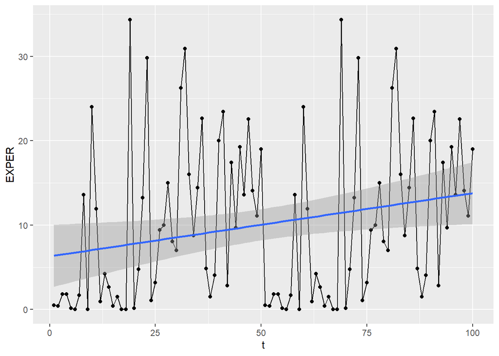

```r
#Run-sequential plot for experience variable
ggplot(employeedata, aes(x=t, y=EXPER)) + geom_line() + geom_point() + geom_smooth(method=lm)
```

The visualization derived from plotting current salary against time suggests that there is fixed location as the line of best fit is fairly parallel to the x-axis but there is no fixed scale as there is inconsistent variation in the data points from the line of best fit.

We investigate for the presence or absence of randomness in the dataset by using lagplots:

```r
library(forecast)
```

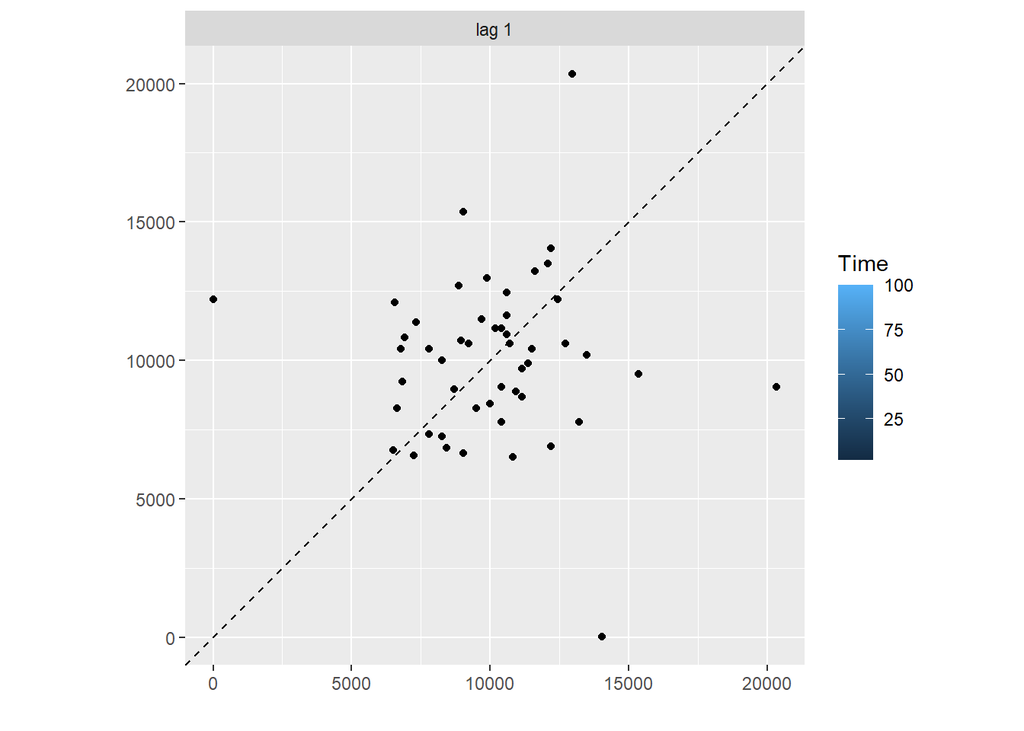

```r
current_sal <- gglagplot(employeedata$CURRENT, set.lag = 1, diag.col = "black",  do.lines = FALSE, colour = TRUE) + geom_point()
current_sal
```

There is no defined structure in the points in the vizualization. Hence the data is random

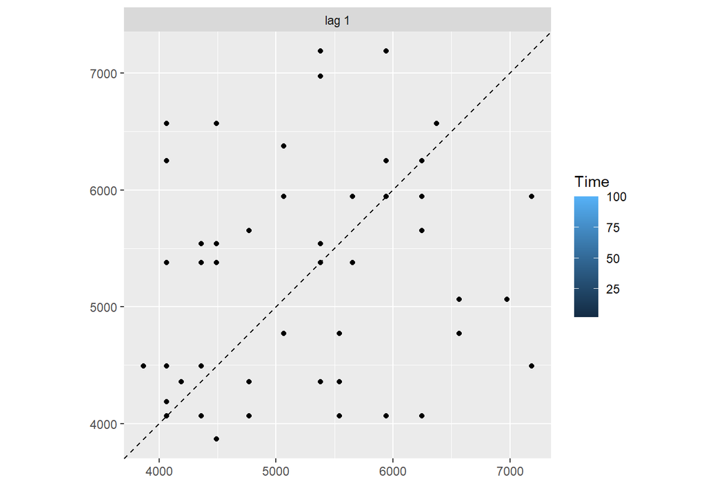

```r
library(forecast)
starting_sal <- gglagplot(employeedata$START, set.lag = 1, diag.col = "black",  do.lines = FALSE, colour = TRUE) + geom_point()
starting_sal
```

Senior

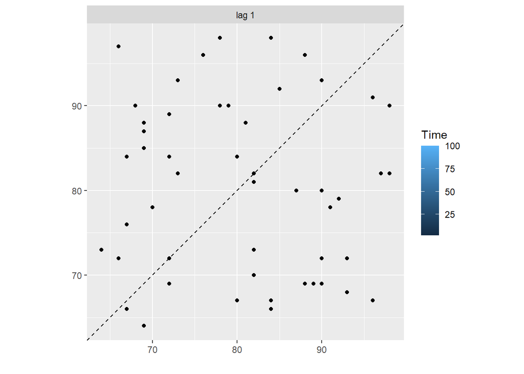

```r
library(forecast)
senior_lag <- gglagplot(employeedata$SENIOR, set.lag = 1, diag.col = "black",  do.lines = FALSE, colour = TRUE) + geom_point()
senior_lag
```

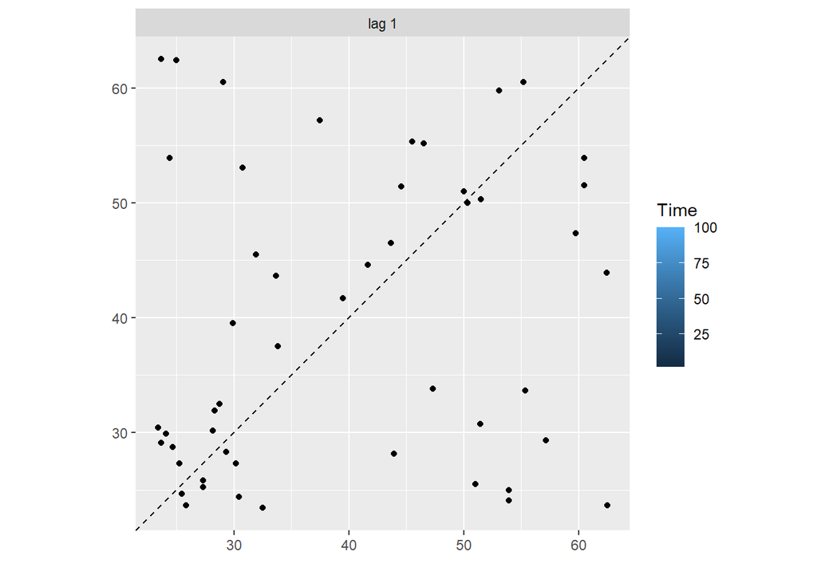

```r
library(forecast)
age_lag <- gglagplot(employeedata$AGE, set.lag = 1, diag.col = "black",  do.lines = FALSE, colour = TRUE) + geom_point()
age_lag
```

Histograms are used to possibly identify the distribution of the data and to delineate the pattern of variation within the data:

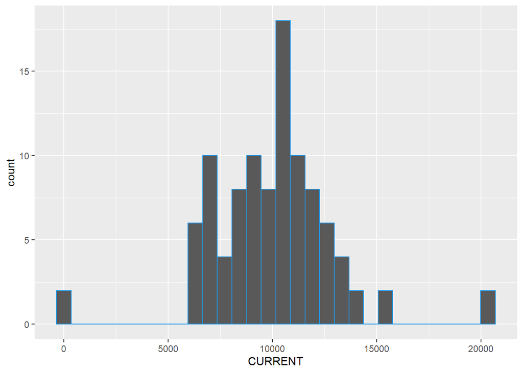

```r
hist_current_sal <-ggplot(employeedata, aes(CURRENT)) + geom_histogram(col = 28)
hist_current_sal
```

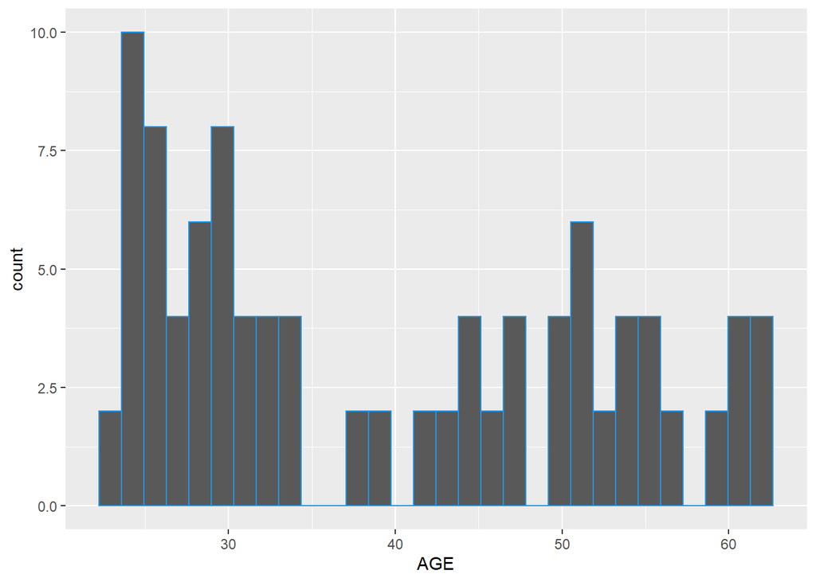

```r
hist_age <-ggplot(employeedata, aes(AGE)) + geom_histogram(col = 28)
hist_age
```

We assess for Univariate Normality in the distribution of the numeric variables in our dataset:

```r
library(psych)
library(tidyverse)
```

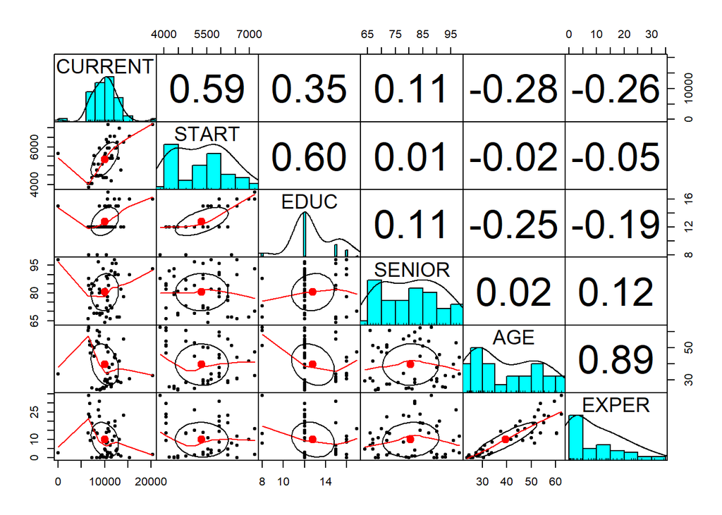

```r
employeedata %>% select (-c(3:5)) %>%
  pairs.panels (gap = 0, cex.cor = 1.5)
```

To test for Multivariate Normality we use the *“heplots”* package.

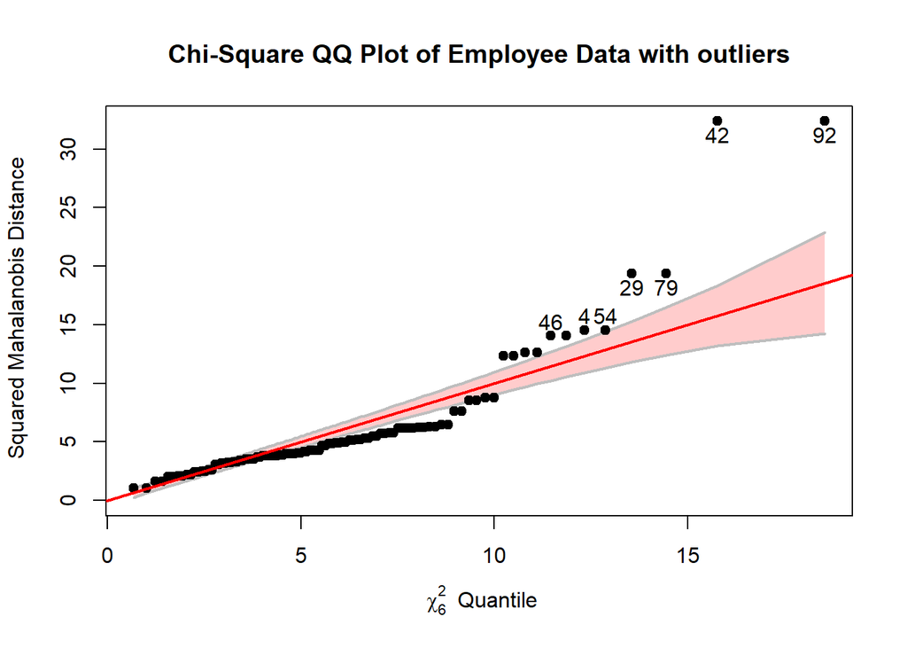

```r
library(heplots)
cqplot (employeedata[ ,-c(3:5)], id.n = 7, main = "Chi-Square QQ Plot of Employee Data with outliers") #Identify outliers
```

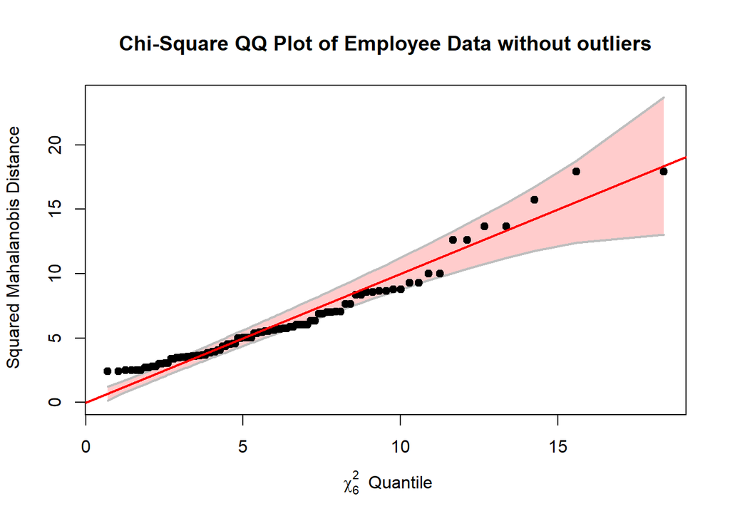

```r
cqplot (employeedata[ -c(4,29,79,42,92,54,46) ,-c(3:5)], main = "Chi-Square QQ Plot of Employee Data without outliers") #Plot without the outliers
```

We develop a parsimonious model. First we identify and extract our important variables.

Model 0: We build a model with variable y as current salary and regress the other variables on our response variable.

We first convert our variables:

```r
library(magrittr)
str(employeedata)
```

```
## 'data.frame':    100 obs. of  9 variables:
##  $ CURRENT: int  11384 9897 12965 20333 9045 15367 9509 8267 7259 6568 ...
##  $ START  : int  4188 4359 5378 7187 4492 6568 5064 4770 4359 4064 ...
##  $ SEX    : chr  "Female" "Female" "Female" "Female" ...
##  $ JOBCAT : chr  "Office trainee" "Office trainee" "Office trainee" "Clerical" ...
##  $ RACE   : chr  "white" "white" "white" "white" ...
##  $ EDUC   : int  12 12 15 16 12 16 12 12 12 12 ...
##  $ SENIOR : int  92 79 90 93 68 90 69 87 80 84 ...
##  $ AGE    : num  25.5 24.7 28.8 32.5 23.4 ...
##  $ EXPER  : num  0.5 0.42 1.83 1.83 0.17 ...
```

```r
employeedata %<>% mutate_if (is.integer, as.numeric)
employeedata %<>% mutate_if (is.character, as.factor)
str(employeedata)
```

```
## 'data.frame':    100 obs. of  9 variables:
##  $ CURRENT: num  11384 9897 12965 20333 9045 ...
##  $ START  : num  4188 4359 5378 7187 4492 ...
##  $ SEX    : Factor w/ 2 levels "Female","Male": 1 1 1 1 1 1 1 1 1 1 ...
##  $ JOBCAT : Factor w/ 3 levels "Clerical","Office trainee",..: 2 2 2 1 2 2 2 1 2 1 ...
##  $ RACE   : Factor w/ 2 levels "nonwhite","white": 2 2 2 2 2 2 2 2 2 2 ...
##  $ EDUC   : num  12 12 15 16 12 16 12 12 12 12 ...
##  $ SENIOR : num  92 79 90 93 68 90 69 87 80 84 ...
##  $ AGE    : num  25.5 24.7 28.8 32.5 23.4 ...
##  $ EXPER  : num  0.5 0.42 1.83 1.83 0.17 ...
```

```r
library(MASS)
library(tidymodels)
library(parameters)
model_0 <- lm(CURRENT~., data = employeedata)
summary(model_0)
```

```
##
## Call:
## lm(formula = CURRENT ~ ., data = employeedata)
##
## Residuals:
##     Min      1Q  Median      3Q     Max
## -8854.3  -811.3   -77.2  1188.1  3128.0
##
## Coefficients:
##                          Estimate Std. Error t value Pr(>|t|)
## (Intercept)             -414.7591  2597.7668  -0.160  0.87351
## START                      2.9256     0.3778   7.744 1.37e-11 ***
## SEXMale                -2280.6864   860.2037  -2.651  0.00947 **
## JOBCATOffice trainee   -1267.5468   514.2994  -2.465  0.01562 *
## JOBCATSecurity officer  2142.2731   945.9073   2.265  0.02593 *
## RACEwhite                678.8215   757.4860   0.896  0.37256
## EDUC                    -263.6837   147.7271  -1.785  0.07764 .
## SENIOR                    38.3039    21.0396   1.821  0.07200 .
## AGE                     -107.5146    42.7437  -2.515  0.01367 *
## EXPER                     35.8225    54.5933   0.656  0.51339
## ---
## Signif. codes:  0 '***' 0.001 '**' 0.01 '*' 0.05 '.' 0.1 ' ' 1
##
## Residual standard error: 1941 on 90 degrees of freedom
## Multiple R-squared:  0.6049, Adjusted R-squared:  0.5654
## F-statistic: 15.31 on 9 and 90 DF,  p-value: 7.988e-15
```

```r
model_parameters(model_0)
```

```
## Parameter                 | Coefficient |      SE |              95% CI | t(90) |      p
## ----------------------------------------------------------------------------------------
## (Intercept)               |     -414.76 | 2597.77 | [-5575.68, 4746.16] | -0.16 | 0.874
## START                     |        2.93 |    0.38 | [    2.18,    3.68] |  7.74 | < .001
## SEX [Male]                |    -2280.69 |  860.20 | [-3989.63, -571.74] | -2.65 | 0.009
## JOBCAT [Office trainee]   |    -1267.55 |  514.30 | [-2289.29, -245.80] | -2.46 | 0.016
## JOBCAT [Security officer] |     2142.27 |  945.91 | [  263.06, 4021.48] |  2.26 | 0.026
## RACE [white]              |      678.82 |  757.49 | [ -826.06, 2183.70] |  0.90 | 0.373
## EDUC                      |     -263.68 |  147.73 | [ -557.17,   29.80] | -1.78 | 0.078
## SENIOR                    |       38.30 |   21.04 | [   -3.49,   80.10] |  1.82 | 0.072
## AGE                       |     -107.51 |   42.74 | [ -192.43,  -22.60] | -2.52 | 0.014
## EXPER                     |       35.82 |   54.59 | [  -72.64,  144.28] |  0.66 | 0.513
```

```r
#To select our important varibales using Stepwise selction
stepAIC(model_0)
```

```
## Start:  AIC=1523.65
## CURRENT ~ START + SEX + JOBCAT + RACE + EDUC + SENIOR + AGE +
##     EXPER
##
##          Df Sum of Sq       RSS    AIC
## - EXPER   1   1621961 340660892 1522.1
## - RACE    1   3025304 342064235 1522.5
## <none>                339038931 1523.7
## - EDUC    1  12001987 351040919 1525.1
## - SENIOR  1  12485854 351524785 1525.3
## - AGE     1  23834057 362872988 1528.4
## - SEX     1  26481071 365520002 1529.2
## - JOBCAT  2  47130005 386168936 1532.7
## - START   1 225908401 564947332 1572.7
##
## Step:  AIC=1522.12
## CURRENT ~ START + SEX + JOBCAT + RACE + EDUC + SENIOR + AGE
##
##          Df Sum of Sq       RSS    AIC
## - RACE    1   4780851 345441743 1521.5
## <none>                340660892 1522.1
## - EDUC    1  10385958 351046850 1523.1
## - SENIOR  1  12661190 353322082 1523.8
## - SEX     1  25847637 366508529 1527.4
## - JOBCAT  2  56584800 397245692 1533.5
## - AGE     1  58623632 399284524 1536.0
## - START   1 255410695 596071587 1576.1
##
## Step:  AIC=1521.52
## CURRENT ~ START + SEX + JOBCAT + EDUC + SENIOR + AGE
##
##          Df Sum of Sq       RSS    AIC
## <none>                345441743 1521.5
## - EDUC    1  14602675 360044418 1523.7
## - SENIOR  1  19344927 364786671 1525.0
## - JOBCAT  2  53193440 398635183 1531.8
## - AGE     1  81934347 427376090 1540.8
## - SEX     1  98658596 444100339 1544.6
## - START   1 275248795 620690538 1578.1
```

```
##
## Call:
## lm(formula = CURRENT ~ START + SEX + JOBCAT + EDUC + SENIOR +
##     AGE, data = employeedata)
##
## Coefficients:
##            (Intercept)                   START                 SEXMale
##               -592.560                   2.886               -2690.653
##   JOBCATOffice trainee  JOBCATSecurity officer                    EDUC
##              -1190.030                2327.244                -265.632
##                 SENIOR                     AGE
##                 45.551                 -91.660
```

```r
pars_model <- lm(formula = CURRENT ~ START + SEX + JOBCAT + EDUC + SENIOR + AGE, data = employeedata)
summary(pars_model)
```

```
##
## Call:
## lm(formula = CURRENT ~ START + SEX + JOBCAT + EDUC + SENIOR +
##     AGE, data = employeedata)
##
## Residuals:
##     Min      1Q  Median      3Q     Max
## -9236.2  -775.2   -33.7  1091.7  3173.5
##
## Coefficients:
##                          Estimate Std. Error t value Pr(>|t|)
## (Intercept)             -592.5598  2359.2689  -0.251   0.8022
## START                      2.8864     0.3371   8.562 2.41e-13 ***
## SEXMale                -2690.6533   524.9087  -5.126 1.63e-06 ***
## JOBCATOffice trainee   -1190.0295   501.0227  -2.375   0.0196 *
## JOBCATSecurity officer  2327.2442   908.2127   2.562   0.0120 *
## EDUC                    -265.6319   134.6969  -1.972   0.0516 .
## SENIOR                    45.5510    20.0682   2.270   0.0256 *
## AGE                      -91.6600    19.6219  -4.671 1.02e-05 ***
## ---
## Signif. codes:  0 '***' 0.001 '**' 0.01 '*' 0.05 '.' 0.1 ' ' 1
##
## Residual standard error: 1938 on 92 degrees of freedom
## Multiple R-squared:  0.5975, Adjusted R-squared:  0.5668
## F-statistic: 19.51 on 7 and 92 DF,  p-value: 8.971e-16
```

```r
model_parameters(pars_model)
```

```
## Parameter                 | Coefficient |      SE |               95% CI | t(92) |      p
## -----------------------------------------------------------------------------------------
## (Intercept)               |     -592.56 | 2359.27 | [-5278.27,  4093.15] | -0.25 | 0.802
## START                     |        2.89 |    0.34 | [    2.22,     3.56] |  8.56 | < .001
## SEX [Male]                |    -2690.65 |  524.91 | [-3733.17, -1648.14] | -5.13 | < .001
## JOBCAT [Office trainee]   |    -1190.03 |  501.02 | [-2185.10,  -194.96] | -2.38 | 0.020
## JOBCAT [Security officer] |     2327.24 |  908.21 | [  523.46,  4131.03] |  2.56 | 0.012
## EDUC                      |     -265.63 |  134.70 | [ -533.15,     1.89] | -1.97 | 0.052
## SENIOR                    |       45.55 |   20.07 | [    5.69,    85.41] |  2.27 | 0.026
## AGE                       |      -91.66 |   19.62 | [ -130.63,   -52.69] | -4.67 | < .001
```

```r
attributes(pars_model)
```

```
## $names
##  [1] "coefficients"  "residuals"     "effects"       "rank"
##  [5] "fitted.values" "assign"        "qr"            "df.residual"
##  [9] "contrasts"     "xlevels"       "call"          "terms"
## [13] "model"
##
## $class
## [1] "lm"
```

```r
pars_model$qr
```

[output not shown]

[output cut: 212 more lines]

While stepwise selection aids in identifying important or significant variables, it does not necessarily combat multi-colinearity.

```r
library(MVA)
```

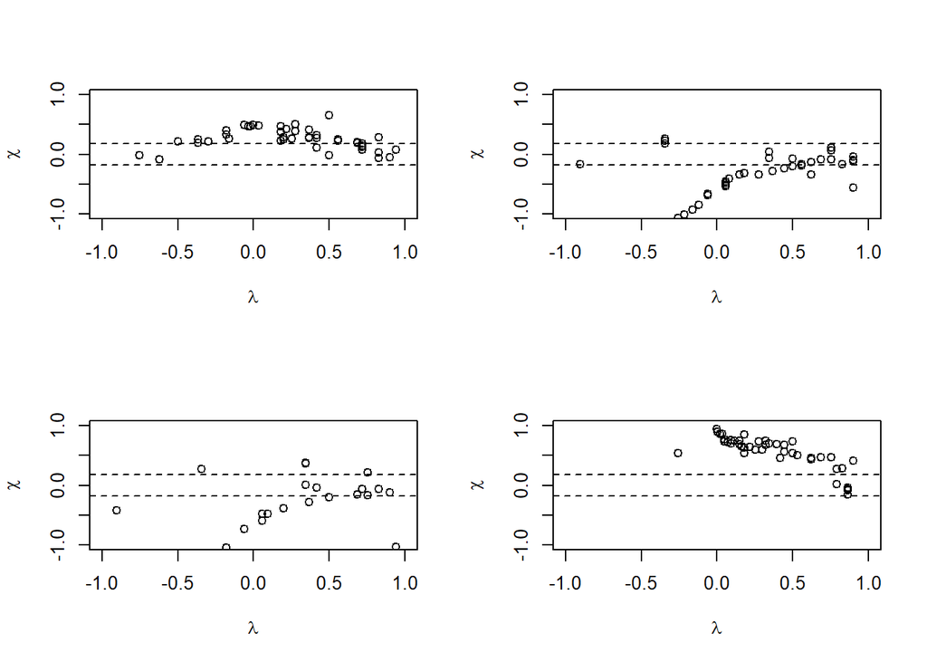

```r
par(mfrow = c (2,2))
chiplot(employeedata$CURRENT, employeedata$START)
chiplot(employeedata$CURRENT, employeedata$EDUC)
chiplot(employeedata$START, employeedata$EDUC)
chiplot(employeedata$AGE, employeedata$EXPER)
```

The visuals indicate dependence. For a linear model the data set fails to meet the independence assumption.

Further from the chisquare plots, the *current* variable was the only normally distributed variable and experience a Chi-square distribution. Therefore the variables in the dataset are not identically distributed.

We can either log transform our variables to be normally distributed or perform a PCA.

We log trasnform our datasets:

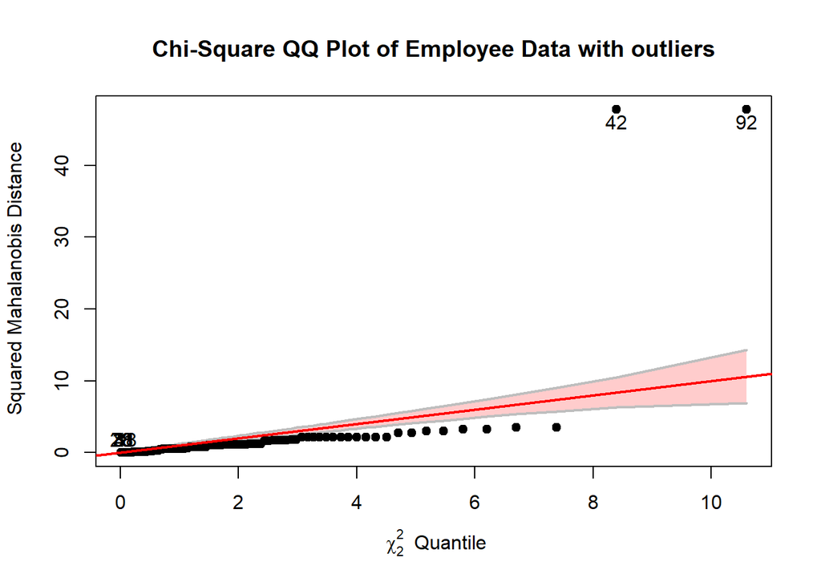

```r
new_employeedata <- log(employeedata[ ,c(1:2,6:8)])

library(heplots)
cqplot (new_employeedata[ ,-c(3:5)], id.n = 7, main = "Chi-Square QQ Plot of Employee Data with outliers") #Identify outliers
```

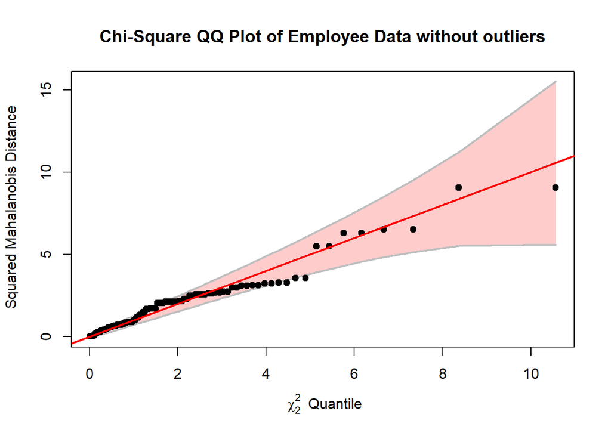

```r
cqplot (new_employeedata[ -c(42,92) ,-c(3:5)], main = "Chi-Square QQ Plot of Employee Data without outliers") #Plot without the outliers
```

We perform a PCA analysis on the dataset:

```r
PCA_employeedata <- princomp(employeedata[ ,-c(1, 3:5)], cor = TRUE, scores = TRUE)
summary(PCA_employeedata, loadings = TRUE)
```

```
## Importance of components:
##                          Comp.1    Comp.2    Comp.3     Comp.4     Comp.5
## Standard deviation     1.433827 1.2195214 0.9933843 0.61041718 0.31222780
## Proportion of Variance 0.411172 0.2974465 0.1973625 0.07452183 0.01949724
## Cumulative Proportion  0.411172 0.7086185 0.9059809 0.98050276 1.00000000
##
## Loadings:
##        Comp.1 Comp.2 Comp.3 Comp.4 Comp.5
## START   0.271  0.650  0.240  0.662
## EDUC    0.406  0.563        -0.711 -0.110
## SENIOR         0.234 -0.959  0.143
## AGE    -0.621  0.304  0.143        -0.708
## EXPER  -0.612  0.337        -0.188  0.689
```

```r
library(factoextra)
```

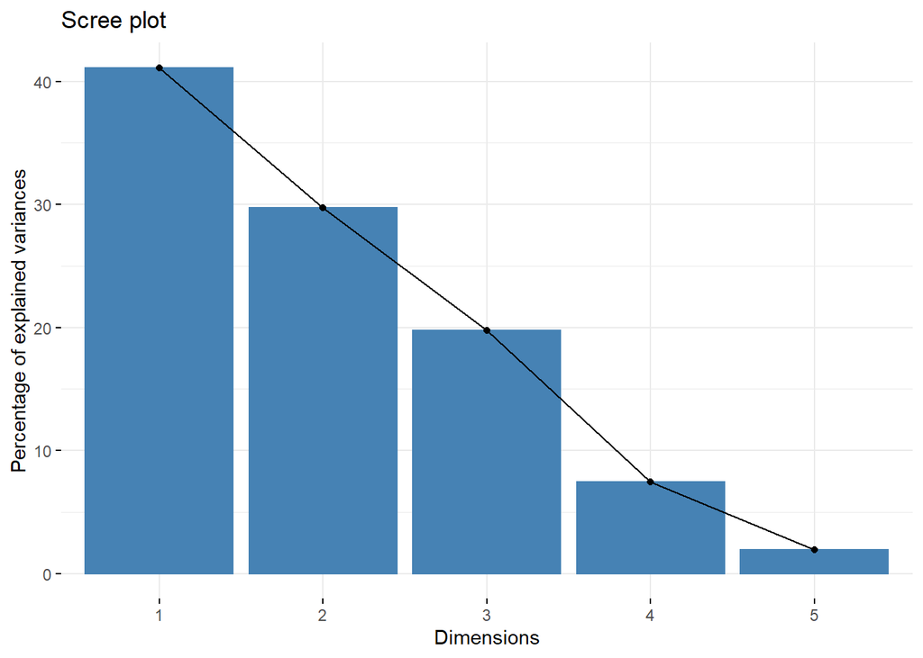

```r
fviz_eig(PCA_employeedata)
```

Work with the cumulative proportion.The linear combination of the variables in our final model is:

```r
Scores <-PCA_employeedata$scores
fit_PCA <- lm(employeedata$CURRENT~ Scores[ ,c(1:2)])
summary(fit_PCA)
```

```
##
## Call:
## lm(formula = employeedata$CURRENT ~ Scores[, c(1:2)])
##
## Residuals:
##      Min       1Q   Median       3Q      Max
## -11886.2  -1161.3   -340.8   1164.9   6708.8
##
## Coefficients:
##                        Estimate Std. Error t value Pr(>|t|)
## (Intercept)             10038.9      244.3  41.093  < 2e-16 ***
## Scores[, c(1:2)]Comp.1    907.3      170.4   5.325 6.53e-07 ***
## Scores[, c(1:2)]Comp.2    860.2      200.3   4.294 4.16e-05 ***
## ---
## Signif. codes:  0 '***' 0.001 '**' 0.01 '*' 0.05 '.' 0.1 ' ' 1
##
## Residual standard error: 2443 on 97 degrees of freedom
## Multiple R-squared:  0.3254, Adjusted R-squared:  0.3115
## F-statistic:  23.4 on 2 and 97 DF,  p-value: 5.103e-09
```

The parsimonious model is:
$$lm (CURRENT \sim 10038.88+907.29PC_1+860.19PC_2)$$